# Lung Adenocarcinoma Analysis (TCGA, GDC)

## PCA by Clinical Variables

To better investigate the potential biological or clinical groupings within the data, the PCA results were visualized with samples colored by key clinical features. These visualizations help assess whether specific sample groupings, observed in lower-dimensional space, correlate with clinical variables such as **vital status**, **primary diagnosis**, **gender**, **race**, **AJCC stage**, or **age at diagnosis**.

Although PCA is an unsupervised method and does not explicitly use class labels during its computation, overlaps or separations between sample groups in PCA plots may reveal biologically meaningful trends.

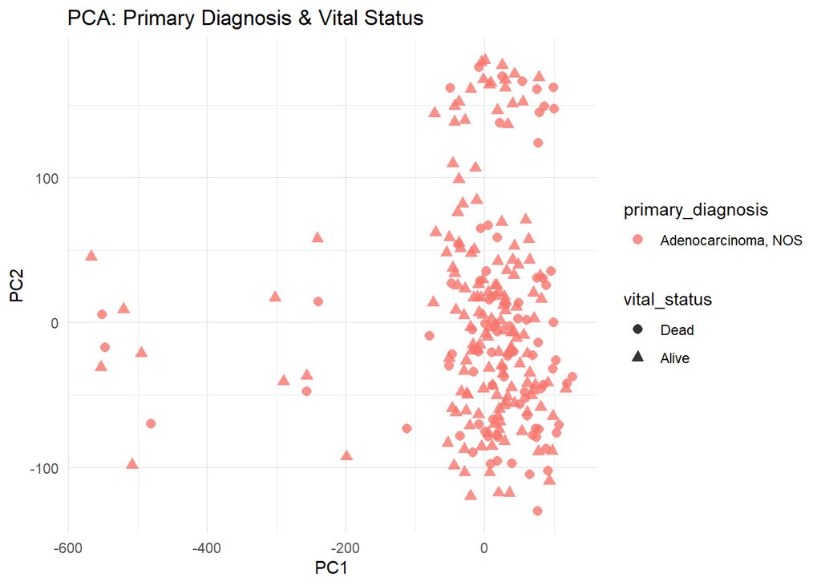

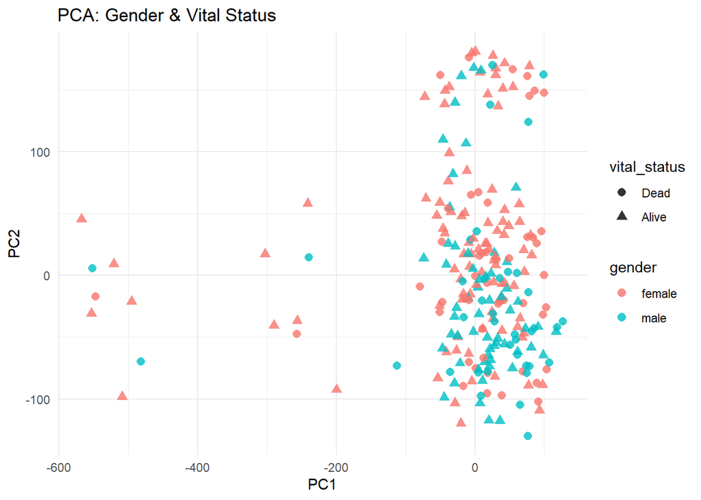

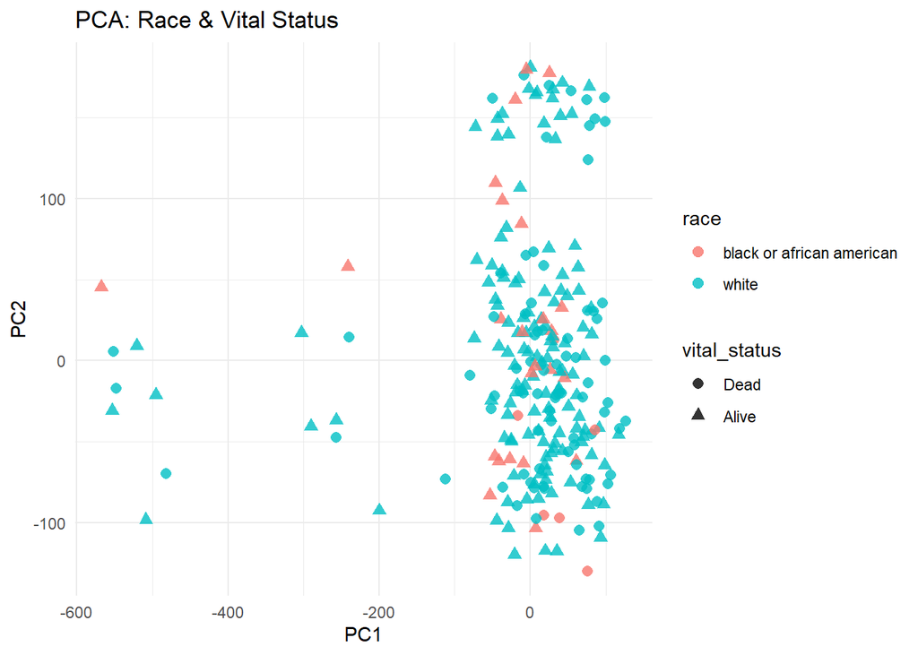

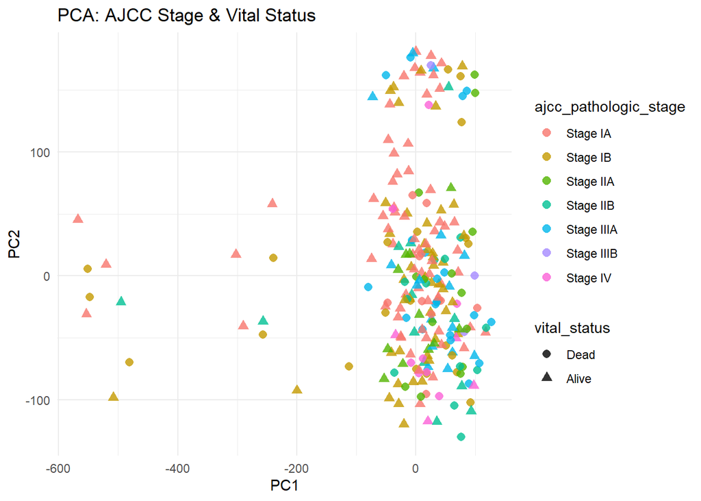

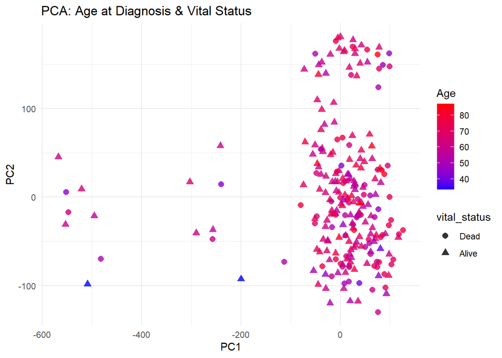

### **Interpretation of PCA by Clinical Variables**

Visualizing the first two principal components after log-transformation, colored by clinical variables, confirms several key limitations of linear dimensionality reduction in this context:

- **No evidence of group separation:** Across all visualizations (primary diagnosis, gender, race, AJCC stage, and age at diagnosis), samples form a dense cloud with extensive overlap between categories. PC1 and PC2 fail to separate any clinical or demographic group, highlighting the **limited clinical interpretability of the first two PCs**.
- **Severe class imbalance in primary diagnosis:** Almost all samples are classified as *Adenocarcinoma, NOS*, which restricts variability and prevents meaningful comparisons for this variable.
- **AJCC stage and age show no clear alignment:** While stages and age are continuous or ordinal variables, the plots show scattered distributions with no visible gradient or directional trend, suggesting **no linear association** with the main components.
- **Gender and race remain mixed:** Samples from different genders and racial groups are completely interspersed, indicating that these demographic factors **do not contribute to major axes of transcriptomic variance** in the data.
- **Vital status does not explain variance:** “Alive” and “Dead” samples overlap entirely, reinforcing that **survival status is not captured by the dominant linear structure** in the dataset.

### **Conclusion and Justification for Nonlinear Methods**

These updated PCA results, using log-transformed data, further emphasize that **linear projections fail to reveal meaningful clinical or biological structure**. The lack of visible grouping supports the need for **nonlinear dimensionality reduction techniques**, which can capture relationships that do not lie along straight axes.

We therefore proceed with:

- **t-Distributed Stochastic Neighbor Embedding (t-SNE)**: optimized to preserve local relationships and uncover subtle patterns.
- **Uniform Manifold Approximation and Projection (UMAP)**: better at preserving both global and local structure, while being faster and more stable for large datasets.

These methods are more suitable for revealing potentially **nonlinear biological variation** that may correspond to latent clinical subtypes.

## t-SNE (t-Distributed Stochastic Neighbor Embedding)

t-SNE is a non-linear dimensionality reduction technique that maps high-dimensional data to a low-dimensional space by preserving the probability distribution of pairwise similarities. It is particularly well-suited to reveal **local clusters** or subgroup patterns that PCA might miss due to its linear nature.

```r
# Remove duplicated rows (required by t-SNE)
rownames(pca_data)
```

[output not shown]

[output cut: 147 more lines]

```r
dados_CPM_nd <- pca_data[!duplicated(pca_data),]
dim(dados_CPM_nd)
```

```
## [1]   323 60660
```

```r
rownames(dados_CPM_nd) <- rownames(pca_data)[!duplicated(pca_data)]


# Run t-SNE
library(Rtsne)
set.seed(42)
res_tsne <- Rtsne(dados_CPM_nd, dims = 2, perplexity = 30, verbose = TRUE)
```

[output not shown]

```r
# Store t-SNE coordinates
tsne_df <- as.data.frame(res_tsne$Y)
colnames(tsne_df) <- c("tSNE1", "tSNE2")
rownames(tsne_df) <- rownames(dados_CPM_nd)

clinical_df_filtered <- clinical_df[rownames(tsne_df), ]
tsne_df_final <- cbind(tsne_df, clinical_df_filtered)
```

Now, we visualize the t-SNE embeddings colored by clinical and demographic attributes:

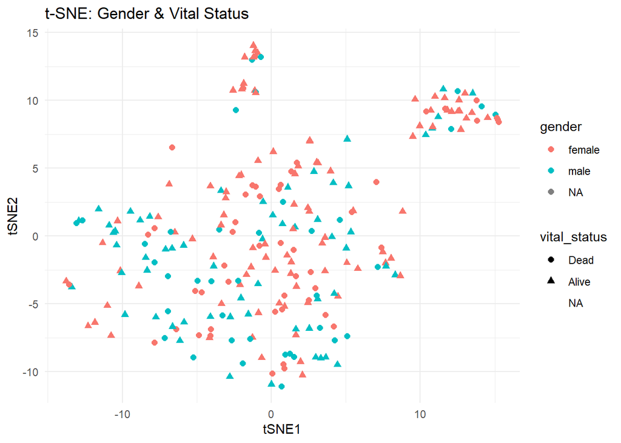

```r
library(ggplot2)

# t-SNE by Vital Status and Gender
ggplot(tsne_df_final, aes(x = tSNE1, y = tSNE2, color = gender, shape = vital_status)) +
  geom_point(size = 2) +
  theme_minimal() +
  labs(title = "t-SNE: Gender & Vital Status")
```

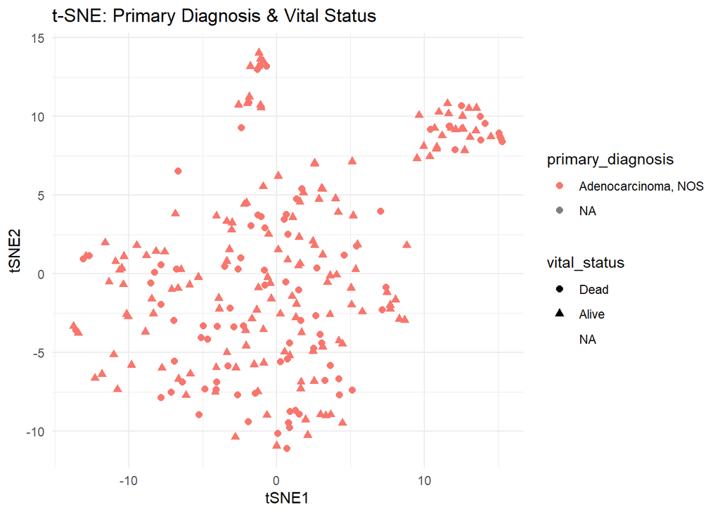

```r
# t-SNE by Primary Diagnosis and Vital Status
ggplot(tsne_df_final, aes(x = tSNE1, y = tSNE2, color = primary_diagnosis, shape = vital_status)) +
  geom_point(size = 2) +
  theme_minimal() +
  labs(title = "t-SNE: Primary Diagnosis & Vital Status")
```

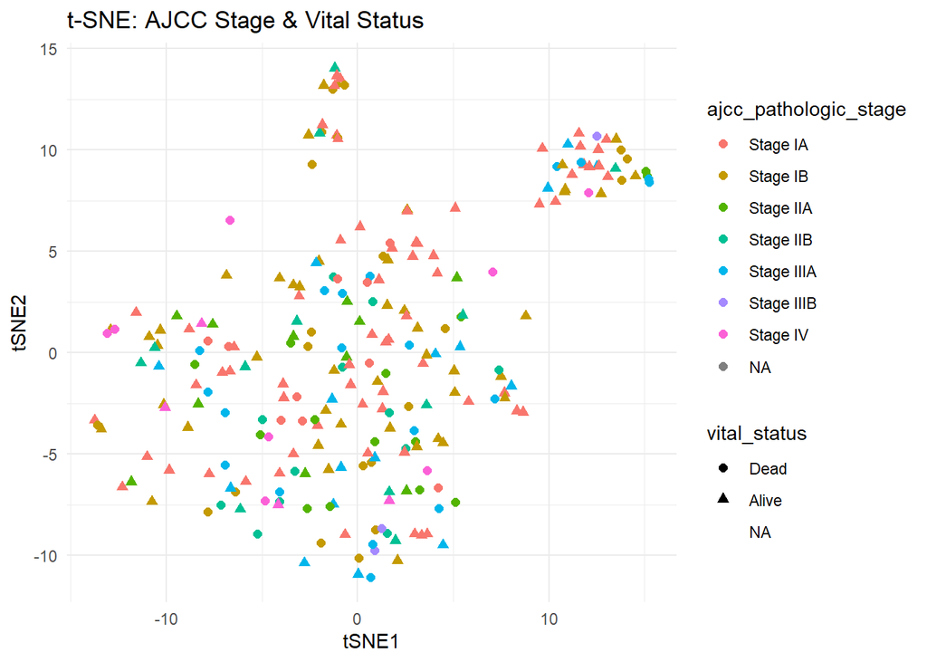

```r
# t-SNE by AJCC Stage and Vital Status
ggplot(tsne_df_final, aes(x = tSNE1, y = tSNE2, color = ajcc_pathologic_stage, shape = vital_status)) +
  geom_point(size = 2) +
  theme_minimal() +
  labs(title = "t-SNE: AJCC Stage & Vital Status")
```

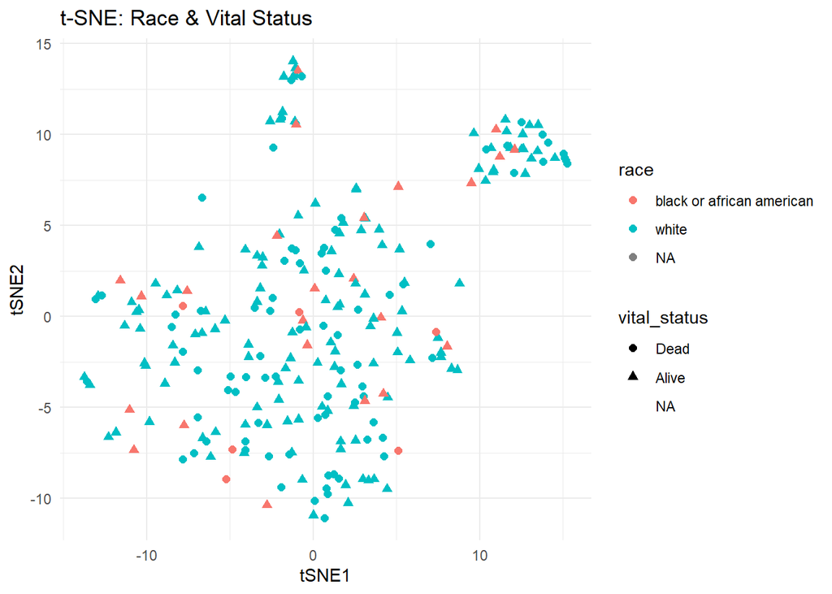

```r
# t-SNE by Race and Vital Status
ggplot(tsne_df_final, aes(x = tSNE1, y = tSNE2, color = race, shape = vital_status)) +
  geom_point(size = 2) +
  theme_minimal() +
  labs(title = "t-SNE: Race & Vital Status")
```

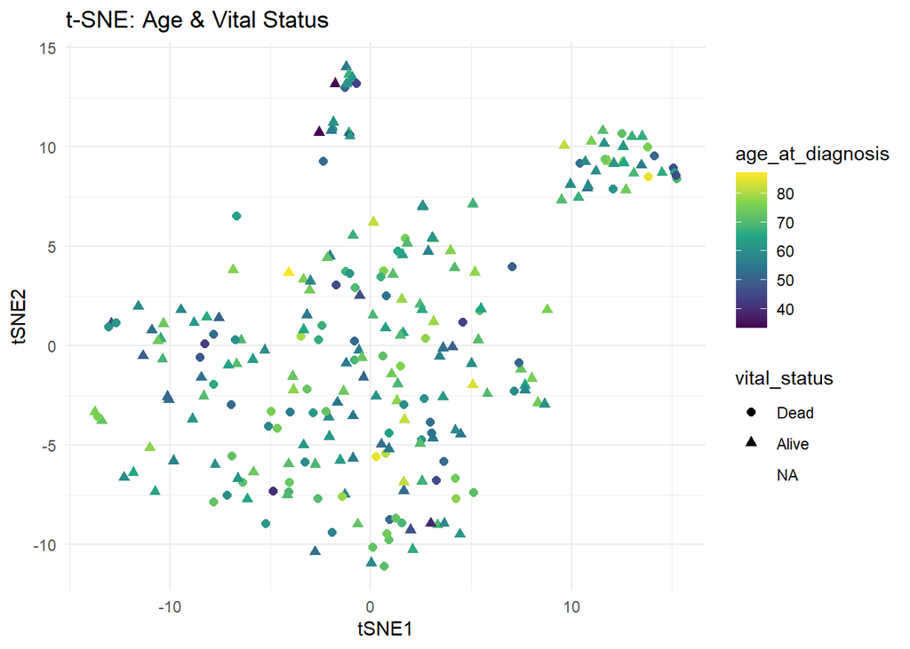

```r
# t-SNE by Age and Vital Status
ggplot(tsne_df_final, aes(x = tSNE1, y = tSNE2, color = age_at_diagnosis, shape = vital_status)) +
  geom_point(size = 2) +
  scale_color_viridis_c() +
  theme_minimal() +
  labs(title = "t-SNE: Age & Vital Status")
```

### **Interpretation of t-SNE by Clinical Variables**

The t-SNE embeddings, computed from log-transformed data, reveal **no clear separation** between clinical or demographic groups. Samples remain largely intermixed across all variables, including **gender**, **race**, **AJCC stage**, **age**, and **vital status**.

While t-SNE exposes some local structure, these patterns **do not align with any of the annotated clinical features**, suggesting that other factors—possibly molecular or technical—drive the observed variation.

These results reinforce the conclusion that **the clinical variables analyzed do not correspond to distinct transcriptomic profiles**, even in a nonlinear embedding.

## UMAP (Uniform Manifold Approximation and Projection)

UMAP is another powerful non-linear method that builds on manifold learning and topological data analysis. Compared to t-SNE, UMAP generally offers **better global structure retention** and can be tuned to emphasize either local or global features.

```r
library(umap)

# Run UMAP
umap_res <- umap(dados_CPM_nd)
umap_df <- as.data.frame(umap_res$layout)
colnames(umap_df) <- c("UMAP1", "UMAP2")
clinical_df_filtered <- clinical_df[rownames(umap_df), ]
umap_df <- cbind(umap_df, clinical_df_filtered)
```

And we visualize the UMAP projection:

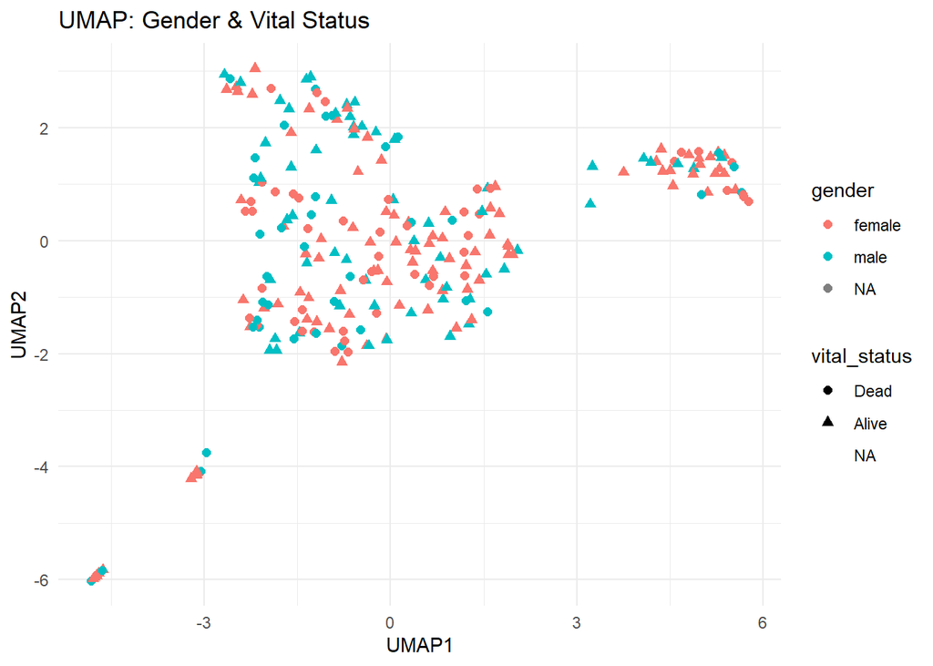

```r
# UMAP by Vital Status and Gender
ggplot(umap_df, aes(x = UMAP1, y = UMAP2, color = gender, shape = vital_status)) +
  geom_point(size = 2) +
  theme_minimal() +
  labs(title = "UMAP: Gender & Vital Status")
```

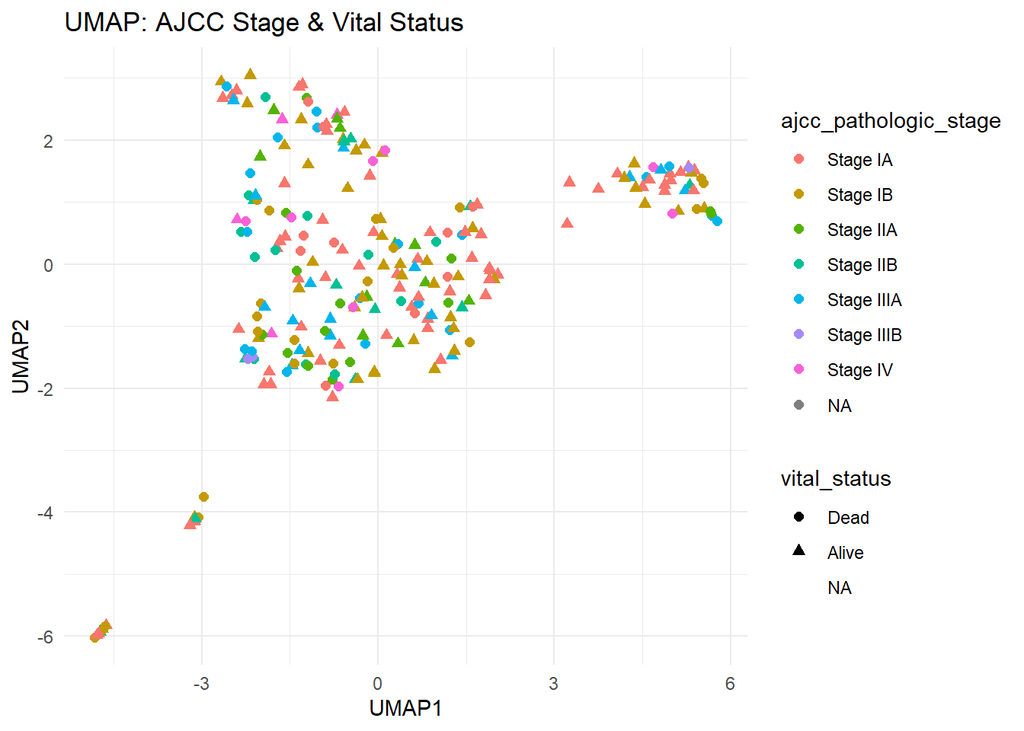

```r
# UMAP by AJCC Stage and Vital Status
ggplot(umap_df, aes(x = UMAP1, y = UMAP2, color = ajcc_pathologic_stage, shape = vital_status)) +
  geom_point(size = 2) +
  theme_minimal() +
  labs(title = "UMAP: AJCC Stage & Vital Status")
```

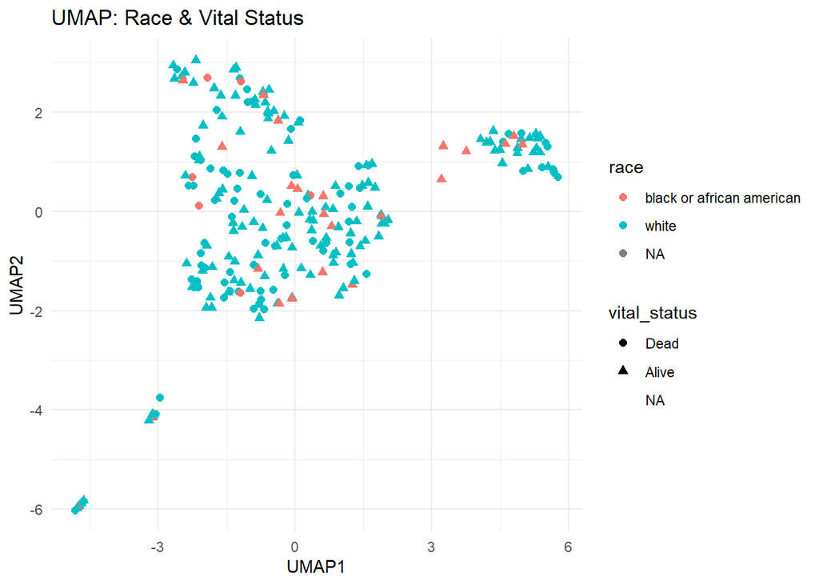

```r
# UMAP by Race and Vital Status
ggplot(umap_df, aes(x = UMAP1, y = UMAP2, color = race, shape = vital_status)) +
  geom_point(size = 2) +
  theme_minimal() +
  labs(title = "UMAP: Race & Vital Status")
```

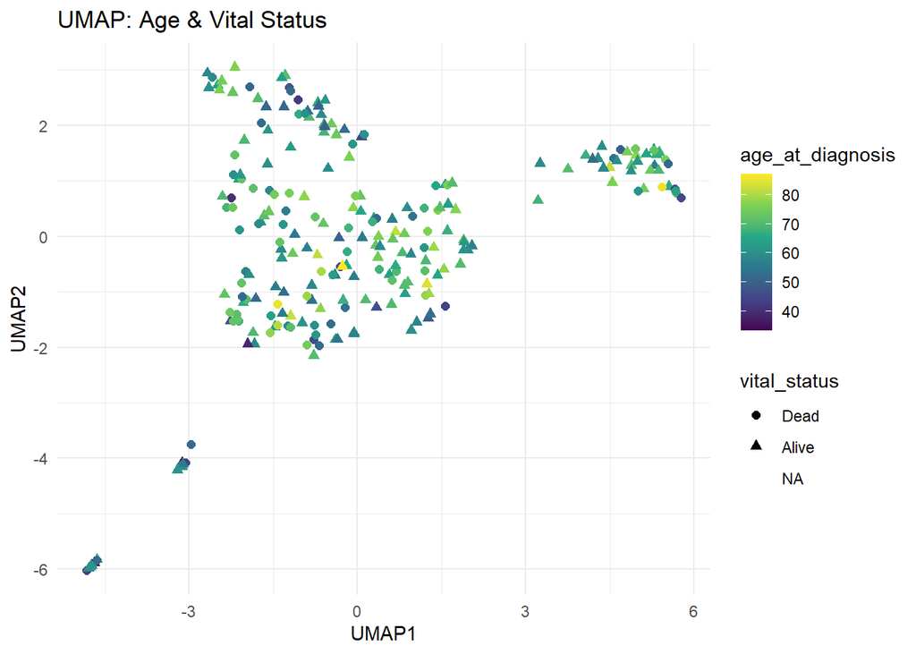

```r
# UMAP by Age and Vital Status
ggplot(umap_df, aes(x = UMAP1, y = UMAP2, color = age_at_diagnosis, shape = vital_status)) +
  geom_point(size = 2) +
  scale_color_viridis_c() +
  theme_minimal() +
  labs(title = "UMAP: Age & Vital Status")
```

### **Interpretation of UMAP by Clinical Variables**

The UMAP projections reveal structured groupings in the transcriptomic space, with some visible clustering. However, these clusters do not align with any of the clinical or demographic variables considered — including **gender**, **race**, **AJCC stage**, **age**, or **vital status**.

This indicates that while UMAP captures meaningful relationships in the data, **the observed structure is likely driven by latent biological or technical factors**, rather than the available clinical annotations.

### **Final Remarks on UMAP**

UMAP projections revealed more defined structures compared to PCA and t-SNE, with denser local groupings and clearer spatial organization. However, these structures did not correspond to the available clinical features, reinforcing the likelihood that **other, unmeasured biological factors** underlie the observed transcriptomic variation.

### Bibliography

1. Myers DJ, Wallen JM. Lung Adenocarcinoma. 2023 Jun 12. In: StatPearls [Internet]. Treasure Island (FL): StatPearls Publishing; 2025 Jan–. PMID: 30137862.
2. Cancer Treatment Centers of America. (n.d.). Adenocarcinoma of the lung. Cancer Treatment Centers of America. https://www.cancercenter.com/cancer-types/lung-cancer/types/adenocarcinoma-of-the-lung
3. American Cancer Society. (n.d.). What is lung cancer? American Cancer Society. https://www.cancer.org/cancer/types/lung-cancer/about/what-is.html
4. Lung Cancer Foundation of America. (n.d.). Adenocarcinoma of the lung: An introduction. Lung Cancer Foundation of America. https://lcfamerica.org/about-lung-cancer/diagnosis/types/adenocarcinoma/